# Note for R (Lec 4-5)

Luo Beier

2022-11-01

# R 语言

首先，我们先介绍一个新的传递数据的方法：**Pipe operator**

## Pipe operator

A key package: **tidyverse**

Suppose that we want to find the following summation:
$$\sqrt{\sum_{i=-10}^{10}|i|}.$$
Base-R, we can:

```r
sqrt(sum(abs(-10:10)))
```

```
## [1] 10.48809
```

We can use pipe operator to deal with multiple functions like this:

```r
library(tidyverse)
-10:10 %>%
  abs() %>%
  sum() %>%
  sqrt()
```

```
## [1] 10.48809
```

**More logical!**

When you have multiple arguments in a function:

```r
matrix(1:10, nrow = 2, byrow = TRUE)
```

```
##      [,1] [,2] [,3] [,4] [,5]
## [1,]    1    2    3    4    5
## [2,]    6    7    8    9   10
```

```r
1:10 %>%
matrix(nrow = 2, byrow = TRUE)
```

```
##      [,1] [,2] [,3] [,4] [,5]
## [1,]    1    2    3    4    5
## [2,]    6    7    8    9   10
```

## 基本数据管理

```r
library(tidyverse)
library(palmerpenguins)
```

### mutate()

我们想再创建一个新的变量:

```r
df <- penguins
attach(df)
df$bill_sum <- bill_length_mm + bill_depth_mm
detach(df)
```

在tidyverse包下，可以使用mutate()函数：

```r
library(tidyverse)
mutate(.data = df, bill_sum = bill_length_mm + bill_depth_mm)
```

```
## # A tibble: 344 × 9
##    species island    bill_length_mm bill_d…¹ flipp…² body_…³ sex    year bill_…⁴
##    <fct>   <fct>              <dbl>    <dbl>   <int>   <int> <fct> <int>   <dbl>
##  1 Adelie  Torgersen           39.1     18.7     181    3750 male   2007    57.8
##  2 Adelie  Torgersen           39.5     17.4     186    3800 fema…  2007    56.9
##  3 Adelie  Torgersen           40.3     18       195    3250 fema…  2007    58.3
##  4 Adelie  Torgersen           NA       NA        NA      NA <NA>   2007    NA
##  5 Adelie  Torgersen           36.7     19.3     193    3450 fema…  2007    56
##  6 Adelie  Torgersen           39.3     20.6     190    3650 male   2007    59.9
##  7 Adelie  Torgersen           38.9     17.8     181    3625 fema…  2007    56.7
##  8 Adelie  Torgersen           39.2     19.6     195    4675 male   2007    58.8
##  9 Adelie  Torgersen           34.1     18.1     193    3475 <NA>   2007    52.2
## 10 Adelie  Torgersen           42       20.2     190    4250 <NA>   2007    62.2
## # … with 334 more rows, and abbreviated variable names ¹bill_depth_mm,
## #   ²flipper_length_mm, ³body_mass_g, ⁴bill_sum
```

```r
## or,
mutate(df, bill_sum = bill_length_mm + bill_depth_mm)
```

```
## # A tibble: 344 × 9
##    species island    bill_length_mm bill_d…¹ flipp…² body_…³ sex    year bill_…⁴
##    <fct>   <fct>              <dbl>    <dbl>   <int>   <int> <fct> <int>   <dbl>
##  1 Adelie  Torgersen           39.1     18.7     181    3750 male   2007    57.8
##  2 Adelie  Torgersen           39.5     17.4     186    3800 fema…  2007    56.9
##  3 Adelie  Torgersen           40.3     18       195    3250 fema…  2007    58.3
##  4 Adelie  Torgersen           NA       NA        NA      NA <NA>   2007    NA
##  5 Adelie  Torgersen           36.7     19.3     193    3450 fema…  2007    56
##  6 Adelie  Torgersen           39.3     20.6     190    3650 male   2007    59.9
##  7 Adelie  Torgersen           38.9     17.8     181    3625 fema…  2007    56.7
##  8 Adelie  Torgersen           39.2     19.6     195    4675 male   2007    58.8
##  9 Adelie  Torgersen           34.1     18.1     193    3475 <NA>   2007    52.2
## 10 Adelie  Torgersen           42       20.2     190    4250 <NA>   2007    62.2
## # … with 334 more rows, and abbreviated variable names ¹bill_depth_mm,
## #   ²flipper_length_mm, ³body_mass_g, ⁴bill_sum
```

```r
## or, using pipe operator:
df %>%
mutate(bill_sum = bill_length_mm + bill_depth_mm)
```

```
## # A tibble: 344 × 9
##    species island    bill_length_mm bill_d…¹ flipp…² body_…³ sex    year bill_…⁴
##    <fct>   <fct>              <dbl>    <dbl>   <int>   <int> <fct> <int>   <dbl>
##  1 Adelie  Torgersen           39.1     18.7     181    3750 male   2007    57.8
##  2 Adelie  Torgersen           39.5     17.4     186    3800 fema…  2007    56.9
##  3 Adelie  Torgersen           40.3     18       195    3250 fema…  2007    58.3
##  4 Adelie  Torgersen           NA       NA        NA      NA <NA>   2007    NA
##  5 Adelie  Torgersen           36.7     19.3     193    3450 fema…  2007    56
##  6 Adelie  Torgersen           39.3     20.6     190    3650 male   2007    59.9
##  7 Adelie  Torgersen           38.9     17.8     181    3625 fema…  2007    56.7
##  8 Adelie  Torgersen           39.2     19.6     195    4675 male   2007    58.8
##  9 Adelie  Torgersen           34.1     18.1     193    3475 <NA>   2007    52.2
## 10 Adelie  Torgersen           42       20.2     190    4250 <NA>   2007    62.2
## # … with 334 more rows, and abbreviated variable names ¹bill_depth_mm,
## #   ²flipper_length_mm, ³body_mass_g, ⁴bill_sum
```

### 选取列 select()

#### 按名称选取

```r
df <- penguins # 初始化 df 变量
df %>% select(bill_length_mm, bill_depth_mm)
```

```
## # A tibble: 344 × 2
##    bill_length_mm bill_depth_mm
##             <dbl>         <dbl>
##  1           39.1          18.7
##  2           39.5          17.4
##  3           40.3          18
##  4           NA            NA
##  5           36.7          19.3
##  6           39.3          20.6
##  7           38.9          17.8
##  8           39.2          19.6
##  9           34.1          18.1
## 10           42            20.2
## # … with 334 more rows
```

```r
df %>% select(-bill_length_mm, -bill_depth_mm) #按名称删除不需要的列
```

```
## # A tibble: 344 × 6
##    species island    flipper_length_mm body_mass_g sex     year
##    <fct>   <fct>                 <int>       <int> <fct>  <int>
##  1 Adelie  Torgersen               181        3750 male    2007
##  2 Adelie  Torgersen               186        3800 female  2007
##  3 Adelie  Torgersen               195        3250 female  2007
##  4 Adelie  Torgersen                NA          NA <NA>    2007
##  5 Adelie  Torgersen               193        3450 female  2007
##  6 Adelie  Torgersen               190        3650 male    2007
##  7 Adelie  Torgersen               181        3625 female  2007
##  8 Adelie  Torgersen               195        4675 male    2007
##  9 Adelie  Torgersen               193        3475 <NA>    2007
## 10 Adelie  Torgersen               190        4250 <NA>    2007
## # … with 334 more rows
```

#### 按名称所含字符选取

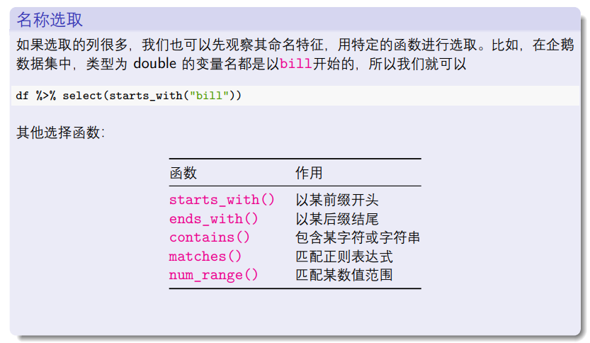

#### 按数值类型选取

```r
df %>% select(where(is.numeric))
```

```
## # A tibble: 344 × 5
##    bill_length_mm bill_depth_mm flipper_length_mm body_mass_g  year
##             <dbl>         <dbl>             <int>       <int> <int>
##  1           39.1          18.7               181        3750  2007
##  2           39.5          17.4               186        3800  2007
##  3           40.3          18                 195        3250  2007
##  4           NA            NA                  NA          NA  2007
##  5           36.7          19.3               193        3450  2007
##  6           39.3          20.6               190        3650  2007
##  7           38.9          17.8               181        3625  2007
##  8           39.2          19.6               195        4675  2007
##  9           34.1          18.1               193        3475  2007
## 10           42            20.2               190        4250  2007
## # … with 334 more rows
```

```r
df %>% select(where(is.double))
```

```
## # A tibble: 344 × 2
##    bill_length_mm bill_depth_mm
##             <dbl>         <dbl>
##  1           39.1          18.7
##  2           39.5          17.4
##  3           40.3          18
##  4           NA            NA
##  5           36.7          19.3
##  6           39.3          20.6
##  7           38.9          17.8
##  8           39.2          19.6
##  9           34.1          18.1
## 10           42            20.2
## # … with 334 more rows
```

#### 混合选取

```r
## 逻辑并
select(df, 条件一 & 条件二)
## 逻辑或
select(df, 条件一 | 条件二)
## 逻辑非
select(df, !条件一)
```

### 修改列名

```r
df %>%
rename(Bill.Length = bill_length_mm,
Bill.Depth = bill_depth_mm,
Flipper.Length = flipper_length_mm,
Body.Mass = body_mass_g) #等号前是新名字，等号后面是老名字
```

```
## # A tibble: 344 × 8
##    species island    Bill.Length Bill.Depth Flipper.Length Body.Mass sex    year
##    <fct>   <fct>           <dbl>      <dbl>          <int>     <int> <fct> <int>
##  1 Adelie  Torgersen        39.1       18.7            181      3750 male   2007
##  2 Adelie  Torgersen        39.5       17.4            186      3800 fema…  2007
##  3 Adelie  Torgersen        40.3       18              195      3250 fema…  2007
##  4 Adelie  Torgersen        NA         NA               NA        NA <NA>   2007
##  5 Adelie  Torgersen        36.7       19.3            193      3450 fema…  2007
##  6 Adelie  Torgersen        39.3       20.6            190      3650 male   2007
##  7 Adelie  Torgersen        38.9       17.8            181      3625 fema…  2007
##  8 Adelie  Torgersen        39.2       19.6            195      4675 male   2007
##  9 Adelie  Torgersen        34.1       18.1            193      3475 <NA>   2007
## 10 Adelie  Torgersen        42         20.2            190      4250 <NA>   2007
## # … with 334 more rows
```

### 按行选取 filter()

比如，我们想要选择species为”Adelie”的这些样本点：

```r
df %>% filter(species == "Adelie")
```

```
## # A tibble: 152 × 8
##    species island    bill_length_mm bill_depth_mm flipper_…¹ body_…² sex    year
##    <fct>   <fct>              <dbl>         <dbl>      <int>   <int> <fct> <int>
##  1 Adelie  Torgersen           39.1          18.7        181    3750 male   2007
##  2 Adelie  Torgersen           39.5          17.4        186    3800 fema…  2007
##  3 Adelie  Torgersen           40.3          18          195    3250 fema…  2007
##  4 Adelie  Torgersen           NA            NA           NA      NA <NA>   2007
##  5 Adelie  Torgersen           36.7          19.3        193    3450 fema…  2007
##  6 Adelie  Torgersen           39.3          20.6        190    3650 male   2007
##  7 Adelie  Torgersen           38.9          17.8        181    3625 fema…  2007
##  8 Adelie  Torgersen           39.2          19.6        195    4675 male   2007
##  9 Adelie  Torgersen           34.1          18.1        193    3475 <NA>   2007
## 10 Adelie  Torgersen           42            20.2        190    4250 <NA>   2007
## # … with 142 more rows, and abbreviated variable names ¹flipper_length_mm,
## #   ²body_mass_g
```

进一步再选取bill_length_mm大于 40 的：

```r
df %>% filter(species == "Adelie",
bill_length_mm > 40)
```

```
## # A tibble: 51 × 8
##    species island    bill_length_mm bill_depth_mm flipper_…¹ body_…² sex    year
##    <fct>   <fct>              <dbl>         <dbl>      <int>   <int> <fct> <int>
##  1 Adelie  Torgersen           40.3          18          195    3250 fema…  2007
##  2 Adelie  Torgersen           42            20.2        190    4250 <NA>   2007
##  3 Adelie  Torgersen           41.1          17.6        182    3200 fema…  2007
##  4 Adelie  Torgersen           42.5          20.7        197    4500 male   2007
##  5 Adelie  Torgersen           46            21.5        194    4200 male   2007
##  6 Adelie  Biscoe              40.6          18.6        183    3550 male   2007
##  7 Adelie  Biscoe              40.5          17.9        187    3200 fema…  2007
##  8 Adelie  Biscoe              40.5          18.9        180    3950 male   2007
##  9 Adelie  Dream               40.9          18.9        184    3900 male   2007
## 10 Adelie  Dream               42.2          18.5        180    3550 fema…  2007
## # … with 41 more rows, and abbreviated variable names ¹flipper_length_mm,
## #   ²body_mass_g
```

### 排序 arrange()

arrange(df, variable)（升序），或者 arrange(df, -variable)（降序）。

也可以对多个变量依次排序。比如先对变量一排序，再对变量二排序，其公式为：

```r
arrange(df, var1, var2)
```

### 合并数据

#### bind_cols(df1,df2,…)

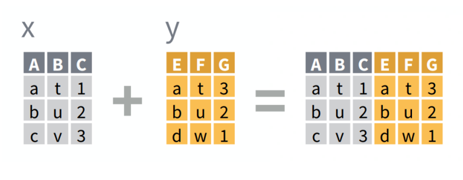

#### 连接数据_join()函数族

左联结 left_join():

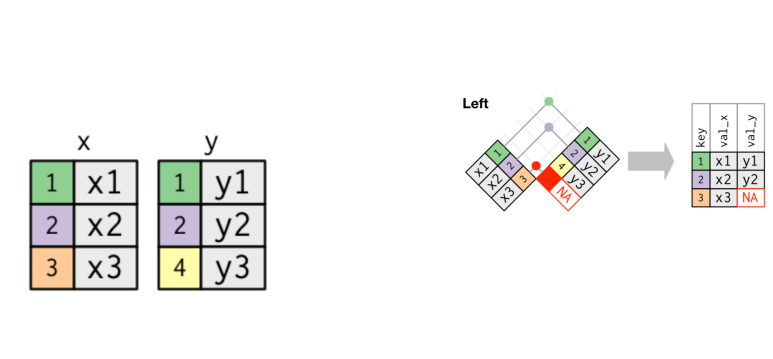

还有右联结right_join(), inner_join和full_join等。

[figure not shown]

### 缺失值

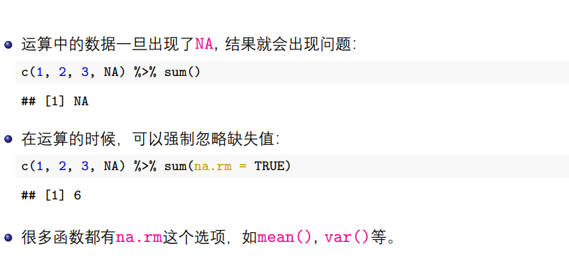

We can also do something to the origianl data to delete the NA value:

```r
mean(penguins$body_mass_g)
```

```
## [1] NA
```

```r
penguins1 <- penguins[complete.cases(penguins),]
mean(penguins1$body_mass_g)
```

```
## [1] 4207.057
```

If we want to delete these na datas, we can use following methods:

```r
na.omit(object)  #Delete the rows which contain na
drop_na(object)    #Delete the columns which contains na
```

### 数据规整

若我们有一组植物的高度数据

```r
plant_height <- data.frame(
Day = 1:5,
A = c(0.7, 1.0, 1.5, 1.8, 2.2),
B = c(0.5, 0.7, 0.9, 1.3, 1.8),
C = c(0.3, 0.6, 1.0, 1.2, 2.2),
D = c(0.4, 0.7, 1.2, 1.5, 3.2)
)
```

此时的数据形如：

```r
plant_height
```

```
##   Day   A   B   C   D
## 1   1 0.7 0.5 0.3 0.4
## 2   2 1.0 0.7 0.6 0.7
## 3   3 1.5 0.9 1.0 1.2
## 4   4 1.8 1.3 1.2 1.5
## 5   5 2.2 1.8 2.2 3.2
```

若我们想将其转化为：

```
## # A tibble: 20 × 3
##      Day plant height
##    <int> <chr>  <dbl>
##  1     1 A        0.7
##  2     1 B        0.5
##  3     1 C        0.3
##  4     1 D        0.4
##  5     2 A        1
##  6     2 B        0.7
##  7     2 C        0.6
##  8     2 D        0.7
##  9     3 A        1.5
## 10     3 B        0.9
## 11     3 C        1
## 12     3 D        1.2
## 13     4 A        1.8
## 14     4 B        1.3
## 15     4 C        1.2
## 16     4 D        1.5
## 17     5 A        2.2
## 18     5 B        1.8
## 19     5 C        2.2
## 20     5 D        3.2
```

则我们需要pivot_longer()来使表格变长：

#### pivot_longer()

上述步骤的代码为：

```r
long <- plant_height %>% pivot_longer(cols = A:D,names_to = "plant",values_to = "height") # cols= 代表需要将哪几列转换成行；names_to=表示转换成行的这几列的名字对应转换后的哪一列；values_to=表示转换成行的这几列的数据对应转换后的哪一列
long
```

```
## # A tibble: 20 × 3
##      Day plant height
##    <int> <chr>  <dbl>
##  1     1 A        0.7
##  2     1 B        0.5
##  3     1 C        0.3
##  4     1 D        0.4
##  5     2 A        1
##  6     2 B        0.7
##  7     2 C        0.6
##  8     2 D        0.7
##  9     3 A        1.5
## 10     3 B        0.9
## 11     3 C        1
## 12     3 D        1.2
## 13     4 A        1.8
## 14     4 B        1.3
## 15     4 C        1.2
## 16     4 D        1.5
## 17     5 A        2.2
## 18     5 B        1.8
## 19     5 C        2.2
## 20     5 D        3.2
```

#### pivot_wider()

同样，我们也有使表格变宽的方法：

```r
wide <- long %>% pivot_wider(names_from = "plant",
values_from = "height") # names_from=表示转换后的表格的列的名字来源；values_from=表示转换后的表格的列的数据来源于
wide
```

```
## # A tibble: 5 × 5
##     Day     A     B     C     D
##   <int> <dbl> <dbl> <dbl> <dbl>
## 1     1   0.7   0.5   0.3   0.4
## 2     2   1     0.7   0.6   0.7
## 3     3   1.5   0.9   1     1.2
## 4     4   1.8   1.3   1.2   1.5
## 5     5   2.2   1.8   2.2   3.2
```

复杂一点的例子：

```r
plant_record <- data.frame(
day = c(1L, 2L, 3L, 4L, 5L),
A_height = c(1.1, 1.2, 1.3, 1.4, 1.5),
A_width = c(2.1, 2.2, 2.3, 2.4, 2.5),
A_depth = c(3.1, 3.2, 3.3, 3.4, 3.5),
B_height = c(4.1, 4.2, 4.3, 4.4, 4.5),
B_width = c(5.1, 5.2, 5.3, 5.4, 5.5),
B_depth = c(6.1, 6.2, 6.3, 6.4, 6.5),
C_height = c(7.1, 7.2, 7.3, 7.4, 7.5),
C_width = c(8.1, 8.2, 8.3, 8.4, 8.5),
C_depth = c(9.1, 9.2, 9.3, 9.4, 9.5)
)
as_tibble(plant_record)
```

```
## # A tibble: 5 × 10
##     day A_height A_width A_depth B_hei…¹ B_width B_depth C_hei…² C_width C_depth
##   <int>    <dbl>   <dbl>   <dbl>   <dbl>   <dbl>   <dbl>   <dbl>   <dbl>   <dbl>
## 1     1      1.1     2.1     3.1     4.1     5.1     6.1     7.1     8.1     9.1
## 2     2      1.2     2.2     3.2     4.2     5.2     6.2     7.2     8.2     9.2
## 3     3      1.3     2.3     3.3     4.3     5.3     6.3     7.3     8.3     9.3
## 4     4      1.4     2.4     3.4     4.4     5.4     6.4     7.4     8.4     9.4
## 5     5      1.5     2.5     3.5     4.5     5.5     6.5     7.5     8.5     9.5
## # … with abbreviated variable names ¹B_height, ²C_height
```

```r
plant_record_longer <- plant_record %>%
tidyr::pivot_longer(
cols = !day,
names_to = c("species", ".value"),
names_pattern = "(.*)_(.*)"
)
plant_record_longer %>% slice(1:10)
```

```
## # A tibble: 10 × 5
##      day species height width depth
##    <int> <chr>    <dbl> <dbl> <dbl>
##  1     1 A          1.1   2.1   3.1
##  2     1 B          4.1   5.1   6.1
##  3     1 C          7.1   8.1   9.1
##  4     2 A          1.2   2.2   3.2
##  5     2 B          4.2   5.2   6.2
##  6     2 C          7.2   8.2   9.2
##  7     3 A          1.3   2.3   3.3
##  8     3 B          4.3   5.3   6.3
##  9     3 C          7.3   8.3   9.3
## 10     4 A          1.4   2.4   3.4
```

变回去：

```r
plant_record_wider <- plant_record_longer %>%
tidyr::pivot_wider(
names_from = species,
values_from = c(height, width, depth),
names_glue = "{species}_{.value}"
)
plant_record_wider
```

```
## # A tibble: 5 × 10
##     day A_height B_hei…¹ C_hei…² A_width B_width C_width A_depth B_depth C_depth
##   <int>    <dbl>   <dbl>   <dbl>   <dbl>   <dbl>   <dbl>   <dbl>   <dbl>   <dbl>
## 1     1      1.1     4.1     7.1     2.1     5.1     8.1     3.1     6.1     9.1
## 2     2      1.2     4.2     7.2     2.2     5.2     8.2     3.2     6.2     9.2
## 3     3      1.3     4.3     7.3     2.3     5.3     8.3     3.3     6.3     9.3
## 4     4      1.4     4.4     7.4     2.4     5.4     8.4     3.4     6.4     9.4
## 5     5      1.5     4.5     7.5     2.5     5.5     8.5     3.5     6.5     9.5
## # … with abbreviated variable names ¹B_height, ²C_height
```

## From data set to a random variables

### summary()

- Working with numbers:
  - center: sample mean, sample median, and so on
  - spread: standard deviation, range, quantiles, IQR(Interquartile range), and so on
  - skewness

```r
body_mass_g <- penguins$body_mass_g
summary(body_mass_g)
```

```
##    Min. 1st Qu.  Median    Mean 3rd Qu.    Max.    NA's
##    2700    3550    4050    4202    4750    6300       2
```

Or we can customize our summary output:

```r
penguins %>%
  summarize(mean = mean(body_mass_g),
            median = median(body_mass_g),
            sd = sd(body_mass_g),
            IQR = IQR(body_mass_g,na.rm=TRUE))
```

```
## # A tibble: 1 × 4
##    mean median    sd   IQR
##   <dbl>  <int> <dbl> <dbl>
## 1    NA     NA    NA  1200
```

If we want to calculate the mean of one particular *species*, we can use **group_by()** and **summarize**

```r
penguins %>%
  group_by(species) %>%
  summarize(n = length(body_mass_g),
            mean = mean(body_mass_g,na.rm = TRUE),
            sd = sd(body_mass_g,na.rm = TRUE))
```

```
## # A tibble: 3 × 4
##   species       n  mean    sd
##   <fct>     <int> <dbl> <dbl>
## 1 Adelie      152 3701.  459.
## 2 Chinstrap    68 3733.  384.
## 3 Gentoo      124 5076.  504.
```

We can add more information like *sex*:

```r
penguins[complete.cases(penguins),]%>%  # 去掉所有的NA
  group_by(species,sex) %>%
  summarize(n = length(body_mass_g),
            mean = mean(body_mass_g,na.rm = TRUE),
            sd = sd(body_mass_g,na.rm = TRUE))
```

```
## # A tibble: 6 × 5
## # Groups:   species [3]
##   species   sex        n  mean    sd
##   <fct>     <fct>  <int> <dbl> <dbl>
## 1 Adelie    female    73 3369.  269.
## 2 Adelie    male      73 4043.  347.
## 3 Chinstrap female    34 3527.  285.
## 4 Chinstrap male      34 3939.  362.
## 5 Gentoo    female    58 4680.  282.
## 6 Gentoo    male      61 5485.  313.
```

### Probability models

#### Joint count:

```r
(joint_table <- penguins %>%
   xtabs(~species + sex, data = .)) %>% # 管道操作时，传过来的数据做为非第一参数时，必须用.代替
  addmargins()   # 计算 sum
```

```
##            sex
## species     female male Sum
##   Adelie        73   73 146
##   Chinstrap     34   34  68
##   Gentoo        58   61 119
##   Sum          165  168 333
```

#### Joint probability

```r
joint_table %>%
  prop.table() %>%
  round(digit = 3) %>% # 保留三位有效数字
  addmargins()
```

```
##            sex
## species     female  male   Sum
##   Adelie     0.219 0.219 0.438
##   Chinstrap  0.102 0.102 0.204
##   Gentoo     0.174 0.183 0.357
##   Sum        0.495 0.504 0.999
```

#### Marginal distribution

```r
library(magrittr)
joint_table %>%
margin.table(1) %T>% #向左传递值到print(),但下一个%>%仍然由margin.table(1)传递而不是print()
print() %>%
prop.table()
```

```
## species
##    Adelie Chinstrap    Gentoo
##       146        68       119
```

```
## species
##    Adelie Chinstrap    Gentoo
## 0.4384384 0.2042042 0.3573574
```

```r
joint_table %>%
margin.table(2) %T>%
print() %>%
prop.table()
```

```
## sex
## female   male
##    165    168
```

```
## sex
##    female      male
## 0.4954955 0.5045045
```

#### Conditional distribution

```r
joint_table %>% prop.table(margin = 1) #已知第一个变量species求条件分布
```

```
##            sex
## species       female     male
##   Adelie    0.500000 0.500000
##   Chinstrap 0.500000 0.500000
##   Gentoo    0.487395 0.512605
```

```r
joint_table %>% prop.table(margin = 2)
```

```
##            sex
## species        female      male
##   Adelie    0.4424242 0.4345238
##   Chinstrap 0.2060606 0.2023810
##   Gentoo    0.3515152 0.3630952
```

#### Draw distribute plot

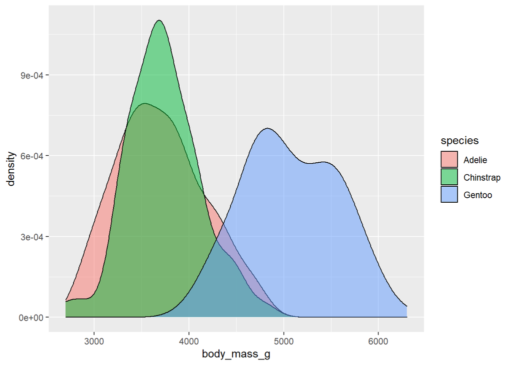

```r
ggplot(data = penguins, aes(x = body_mass_g, y = ..density.., fill = species)) +
  geom_density(color = "black", alpha = 0.5)
```

Sometimes we can also use **boxplot()**

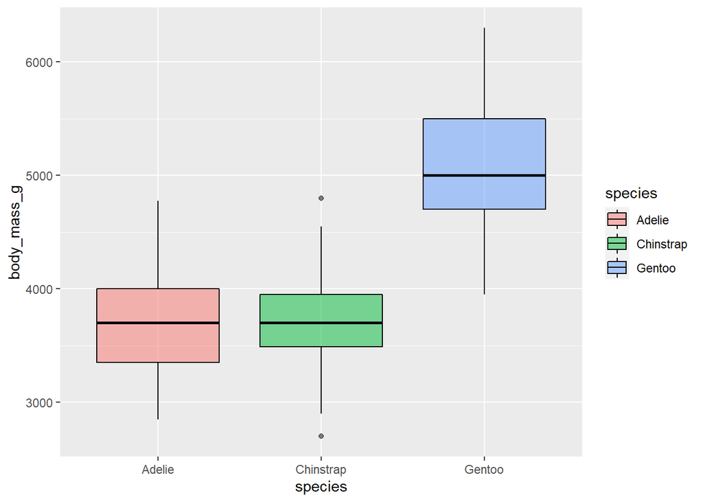

```r
ggplot(data = penguins, aes(x=species, y=body_mass_g, fill=species)) +
  geom_boxplot(color="black", alpha=0.5)
```

#### Calculate Sample Mean and Covariance

**Mean**

```r
penguins1 %>%
  select(where(is.numeric)) %>%
  colMeans() %>%
  knitr::kable()  # 用表格表示
```

|  | x |
| --- | --- |
| bill_length_mm | 43.99279 |
| bill_depth_mm | 17.16486 |
| flipper_length_mm | 200.96697 |
| body_mass_g | 4207.05706 |
| year | 2008.04204 |

**Covariance Matrix**

```r
penguins1 %>%
  select(where(is.numeric)) %>%
  rename(X1 = bill_length_mm,
         X2 = bill_depth_mm,
         X3 = flipper_length_mm,
         X4 = body_mass_g,
         X5 = year) %>%  #改名防止矩阵名字过长影响美观
  var() %>%
  round(digit = 2) %>%
  knitr:: kable()
```

|  | X1 | X2 | X3 | X4 | X5 |
| --- | --- | --- | --- | --- | --- |
| X1 | 29.91 | -2.46 | 50.06 | 2595.62 | 0.15 |
| X2 | -2.46 | 3.88 | -15.95 | -748.46 | -0.08 |
| X3 | 50.06 | -15.95 | 196.44 | 9852.19 | 1.72 |
| X4 | 2595.62 | -748.46 | 9852.19 | 648372.49 | 14.31 |
| X5 | 0.15 | -0.08 | 1.72 | 14.31 | 0.66 |

**Correlation Matrix**

```r
penguins1 %>%
  select(where(is.numeric)) %>%
  rename(X1 = bill_length_mm,
         X2 = bill_depth_mm,
         X3 = flipper_length_mm,
         X4 = body_mass_g,
         X5 = year) %>%  #改名防止矩阵名字过长影响美观
  cor() %>%
  round(digit = 2) %>%
  knitr:: kable()
```

|  | X1 | X2 | X3 | X4 | X5 |
| --- | --- | --- | --- | --- | --- |
| X1 | 1.00 | -0.23 | 0.65 | 0.59 | 0.03 |
| X2 | -0.23 | 1.00 | -0.58 | -0.47 | -0.05 |
| X3 | 0.65 | -0.58 | 1.00 | 0.87 | 0.15 |
| X4 | 0.59 | -0.47 | 0.87 | 1.00 | 0.02 |
| X5 | 0.03 | -0.05 | 0.15 | 0.02 | 1.00 |

## Generate random variables by the build-in functions

### Common probability distributions

| Letter | Description |
| --- | --- |
| d | density |
| p | probability, distribution function |
| q | quantile function |
| r | random generation |

For example:

```r
dnorm(0)#Normal distribution 的f(x)在x=0处的值
```

```
## [1] 0.3989423
```

```r
pnorm(0)#F(0)
```

```
## [1] 0.5
```

```r
qnorm(0.25)#Normal distribution 的F(x)小于等于0.25时x的值
```

```
## [1] -0.6744898
```

```r
rnorm(100) #生成n个服从Normal distribution的点
```

```
##   [1] -0.127543671  0.466886424  0.162908207 -0.663704757  0.400237895
##   [6]  0.282903161 -0.384530289 -0.772029580 -1.127010942 -0.203657302
##  [11] -1.641884667  0.979661888 -0.050906293  0.691506326  0.309889034
##  [16] -0.425184584 -1.000546410  0.436142379 -0.895887302  0.473619421
##  [21]  0.232505501 -1.868191473  0.450216309  0.961345584 -0.248261131
##  [26] -1.952083830 -0.420792739 -0.297715198  0.820571758 -1.489687325
##  [31]  0.312014869 -0.166939858  0.113216664 -0.384481664 -0.499031372
##  [36]  0.849299499  0.495916981  0.182589037  1.715255344  0.771427564
##  [41]  0.309939782 -0.418204658  0.702207320 -1.601288853 -0.178787129
##  [46]  0.295563543 -0.367635850  0.336466468  1.617506257  1.487117144
##  [51]  1.280095216 -0.452157592  0.892681567  0.810498334 -2.071575894
##  [56]  0.473152997 -1.221869866  1.916001795 -0.204354782 -0.988323806
##  [61] -0.645296201  0.237897407 -1.154000138  1.050938109 -0.260746117
##  [66]  0.932674682 -1.590705424 -0.749847935 -0.155999572 -2.162606348
##  [71]  1.187401748 -0.842938757  0.677270184  2.223657692  1.787398239
##  [76]  0.308908514  0.450502588 -0.003985335  1.171902907  0.145417246
##  [81] -1.228855872 -0.005232184 -0.801885009 -1.226044629  1.045830638
##  [86] -0.073403045 -0.423216400  0.075468123  1.981621552  0.825275115
##  [91]  3.370666419 -0.122700111  0.307350372  0.025131944  0.824082134
##  [96] -0.522612339 -0.002244836 -0.716576299 -0.066534302 -1.688581385
```

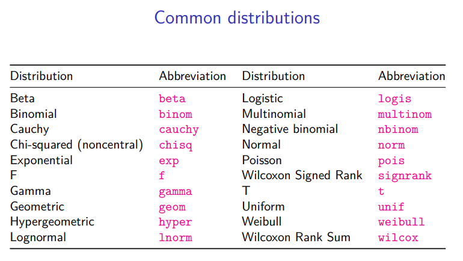

### Generate normal random variables

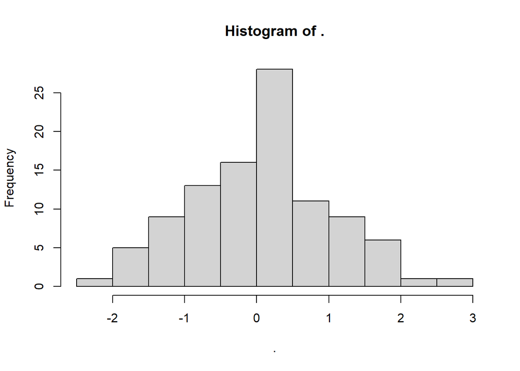

```r
rnorm(100,mean=0,sd=1) %>%
  hist()
```

```r
rnorm(100) %>%
  summary()
```

```
##     Min.  1st Qu.   Median     Mean  3rd Qu.     Max.
## -2.49056 -0.69805 -0.12458 -0.06607  0.74266  2.52630
```

### Generate multivariate normal random variables

```r
library(MASS)
```

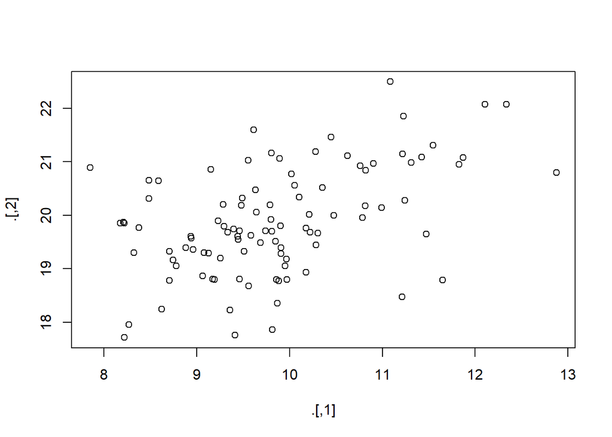

```r
set.seed(1234)
mu <- c(10, 20)
sigma <- matrix(c(1, 0.5, 0.5, 1), nrow = 2)
mvrnorm(100, mu, sigma) %>%
plot()
```